# Mestrado em Hemoterapia: Bioestatística

## Testes de Independência e Homogeneidade

## Tabela de contingência

Quando dois ou mais atributos são observados para cada elemento amostrado, os dados podem ser simultaneamente classificados com respeito aos níveis de ocorrência para cada um dos atributos.

> Por exemplo, empregados podem ser classificados de acordo com escolaridade e tipo de ocupação, flores podem ser classificadas com respeito ao tipo de folhagem e tamanho.

**Tabela de contingência:** enumerar a frequência de obervações da classificação simultânea de duas ou mais características.

Podemos usar a tabela de contingência para estudar se certa característica parece se manifestar independentemente da outra ou se níveis de uma característica tendem a estar associados com níveis da outra.

## Exemplo: Racionamento de energia

Uma amostra aleatória de 500 pessoas responde um questionário sobre filiação partidária (partido \(A\) ou \(B\)) e atitude mediante um programa de racionamento de energia. Os resultados estão apresentados na tabela de contingência a seguir:

|  | Favorável | Indiferente | Contrário |
| --- | --- | --- | --- |
| A | 138 | 83 | 64 |
| B | 64 | 67 | 84 |

Os dados indicam que a opinião sobre racionamento de energia é independente da filiação partidária?

Podemos medir quantitativamente a associaçãoo entre as duas características?

## Exemplo: Racionamento de energia

Primeiramente, consideremos a tabela de um ponto de vista descritivo, transformando as contagens em proporcões.

- Proporções por caselas

|  | Favorável | Indiferente | Contrário | Total |
| --- | --- | --- | --- | --- |
| A | 0.28 | 0.17 | 0.13 | 0.57 |
| B | 0.13 | 0.13 | 0.17 | 0.43 |
| Total | 0.4 | 0.3 | 0.3 | 1.00 |

## Exemplo: Racionamento de energia

Primeiramente, consideremos a tabela de um ponto de vista descritivo, transformando as contagens em proporcões.

- Proporções por linhas

|  | Favorável | Indiferente | Contrário | Total |
| --- | --- | --- | --- | --- |
| A | 0.48 | 0.29 | 0.22 | 1.00 |
| B | 0.3 | 0.31 | 0.39 | 1.00 |

## Exemplo: Racionamento de energia

Primeiramente, consideremos a tabela de um ponto de vista descritivo, transformando as contagens em proporcões.

- Proporções por colunas

|  | Favorável | Indiferente | Contrário |
| --- | --- | --- | --- |
| A | 0.68 | 0.55 | 0.43 |
| B | 0.32 | 0.45 | 0.57 |
| Total | 1.00 | 1.00 | 1.00 |

## Exemplo: Racionamento de energia

- Gráficos de barras: Frequências relativas (caselas, linhas e colunas)

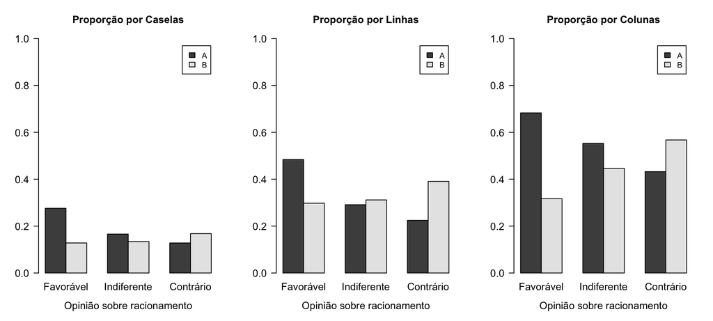

## Exemplo: Racionamento de energia

Através das tabelas de proporções e gráficos de barras, observam-se diferenças aparentes nas distribuições ao longo das linhas, colunas ou das proporções totais das respostas.

Por exemplo, com relação às proporções por linha, observa-se que as proporções diminuem ao longo da primeira linha e aumentam ao longo da segunda.

Podemos usar um teste estatístico para avaliar possível associação entre filiação partidária e opinião com relação ao programa de racionamento de energia.

## Teste de Independência

Considere duas características designadas por \(A\) e \(B\) e suponha que existem \(r\) categorias \(A_1,A_2, \ldots , A_r\) para \(A\) e \(c\) categorias \(B_1, B_2, \ldots, B_c\) para \(B\).

Suponha que uma amostra de tamanho \(n\) é classificada e distribuída nas classes de \(A\) e \(B\), produzindo uma tabela de contingência em que:

\(n_{ij}=\) frequência de observações com as características \(A_i\) e \(B_j\) conjuntamente.

\(n_{i0}=\) total da \(i\)-ésima linha, ou frequência de \(A_i\).

\(n_{0j}=\) total da \(j\)-ésima coluna, ou frequência de \(B_j\).

## Teste de Independência

|  | \(B_1\) | \(B_2\) | \(\ldots\) | \(B_c\) | Total da linha |
| --- | --- | --- | --- | --- | --- |
| \(A_1\) | \(n_{11}\) | \(n_{12}\) | \(\ldots\) | \(n_{1c}\) | \(n_{10}\) |
| \(A_2\) | \(n_{21}\) | \(n_{22}\) | \(\ldots\) | \(n_{2c}\) | \(n_{20}\) |
| \(\vdots\) | \(\vdots\) | \(\vdots\) | \(\vdots\) | \(\vdots\) | \(\vdots\) |
| \(A_r\) | \(n_{r1}\) | \(n_{r2}\) | \(\ldots\) | \(n_{rc}\) | \(n_{r0}\) |
| Total da coluna | \(n_{01}\) | \(n_{02}\) | \(\ldots\) | \(n_{0c}\) | \(n\) |

## Teste de Independência

Podemos usar a população classificada em termos de proporções populacionais e a tabela anterior fica:

|  | \(B_1\) | \(B_2\) | \(\ldots\) | \(B_c\) | Total da linha |
| --- | --- | --- | --- | --- | --- |
| \(A_1\) | \(p_{11}\) | \(p_{12}\) | \(\ldots\) | \(p_{1c}\) | \(p_{10}\) |
| \(A_2\) | \(p_{21}\) | \(p_{22}\) | \(\ldots\) | \(p_{2c}\) | \(p_{20}\) |
| \(\vdots\) | \(\vdots\) | \(\vdots\) | \(\vdots\) | \(\vdots\) | \(\vdots\) |
| \(A_r\) | \(p_{r1}\) | \(p_{r2}\) | \(\ldots\) | \(p_{rc}\) | \(p_{r0}\) |
| Total da coluna | \(p_{01}\) | \(p_{02}\) | \(\ldots\) | \(p_{0c}\) | \(1\) |

\(p_{ij}=P(A_i \cap B_j)\) é a probabilidade da ocorrência conjunta de \(A_i\) e \(B_j\).

\(p_{i0}=P(A_{i})\) é a probabilidade total da \(i\)-ésima linha.

\(p_{0j}=P(B_{j})\) é a probabilidade total da \(j\)-ésima coluna.

## Teste de Independência

**Teste de independência:** interesse é testar se as classificações nas categorias de \(A\) e \(B\) são independentes, ou seja, pretende-se avaliar se \[P(A_i\cap B_j)=P(A_i)P(B_j)\] para todo \(i=1,2, \ldots , r\) e \(j=1,2, \ldots , c\)

## Teste de Independência

**Hipóteses:**

\(H_0: p_{ij}=p_{i0}p_{0j}\) para todas as componentes \((i,j)\) (**independência**)

> \(H_a: p_{ij} \neq p_{i0}p_{0j}\) para pelo menos um par \((i,j)\)

> O modelo de independência especifica as probabilidades das componentes em termo das probabilidades marginais. **Problema:** as probabilidades marginais são parâmetros desconhecidos.

> Como \(p_{i0}=P(A_i)\), um estimador natural é a frequência relativa amostra de \(A_i\),

> \(\displaystyle \hat{p}_{i0}=\frac{n_{i0}}{n}\)

> Da mesma forma, \(p_{0j}=P(B_j)\) é estimado por

> \(\displaystyle \hat{p}_{0j}=\frac{n_{0j}}{n}\)

## Teste de Independência

Usando essas estimativas a probabilidade da componente \((i,j)\) é estimada por \[\hat{p}_{ij}=\hat{p}_{i0}\hat{p}_{0j}=\frac{n_{i0}n_{0j}}{n^2}\]

Logo, a frequência relativa esperada sob o modelo de independência é

\[E_{ij}=n \hat{p}_{ij} = \frac{n_{i0}n_{0j}}{n}\]

Portanto, a **estatística do teste** é dada por:

\[\chi^2= \sum_{r\times c \text{ componentes }}\frac{(O_{ij}-E_{ij})^2}{E_{ij}} = \sum_{r\times c \text{ componentes }}\frac{(n_{ij}-E_{ij})^2}{E_{ij}}\]

que sob \(H_0\) tem distribuição aproximadamente \(\chi^2\) com \((r-1)\times(c-1)\) graus de liberdade, para \(n\) grande.

## Teste de Independência

**Valor Crítico**: Para um nível de significância \(\alpha\), encontrar o valor crítico \(\chi^2_{crit}\) na tabela Chi-quadrado tal que \(P(\chi^2_{(r-1)(c-1)} \geq \chi^2_{crit}) = \alpha.\)

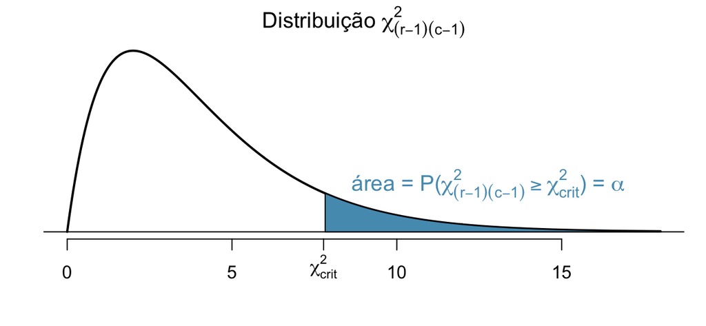

**Conclusão**: Rejeitamos \(H_0\) se \(\chi_{obs}^2 \geq \chi^2_{crit}.\)

## Exemplo: Racionamento de energia

Frequências observadas (\(n_{ij}\)):

|  | Favorável | Indiferente | Contrário |
| --- | --- | --- | --- |
| A | 138 | 83 | 64 |
| B | 64 | 67 | 84 |

Frequências esperadas (\(E_{ij}\)), segundo hipótese de independência:

|  | Favorável | Indiferente | Contrário |
| --- | --- | --- | --- |
| A | 115.14 | 85.5 | 84.36 |
| B | 86.86 | 64.5 | 63.64 |

## Exemplo: Racionamento de energia

A estatística \(\chi^2\) tem o valor observado de

\[\chi^2_{obs}=4.539 + 0.073 + 4.914 + 6.016 + 0.097 + 6.514=22.15 \stackrel{H_0}{\sim} \chi^2_{2}\]

Usando o nível de significância \(\alpha=0.05\), o valor crítico é \(\chi^2_{crit} = \chi^2_{2, 0.05} = 5.99\).

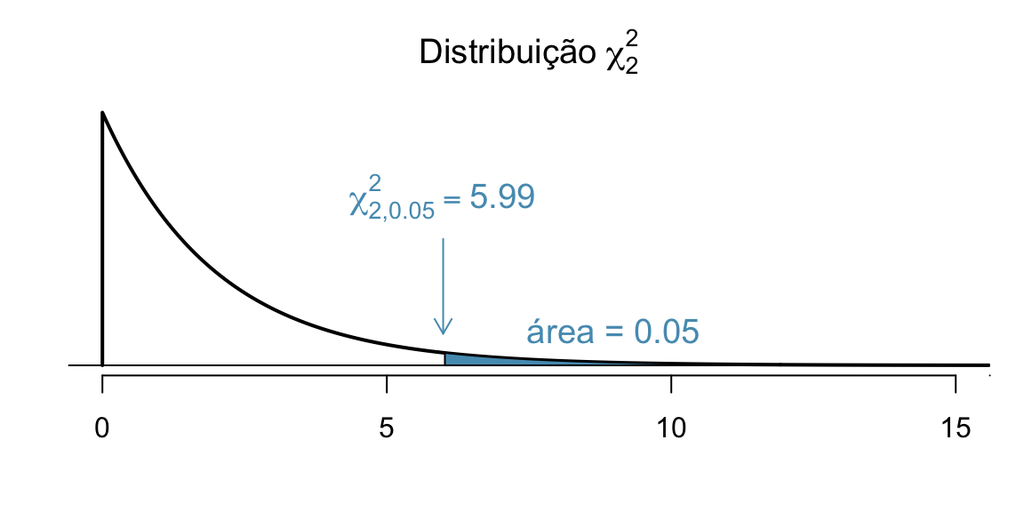

## Exemplo: Racionamento de energia

Como \(\chi^2_{obs}= 22.15 > 5.99 = \chi^2_{crit}\), rejeitamos a hipótese nula de indepêndencia.

Concluímos que os dados trazem evidências de **associação** entre as duas características (filiação e opinião).

**CUIDADO!!!** Associação não implica CAUSA.

Não podemos afirmar que existe uma relação de causa e efeito, pois os dados são observacionais, isto é, não aleatorizamos as pessoas para serem do partido \(A\) ou \(B\), por exemplo.

## Exemplo: Gênero e escolha da carreira

Existe associação entre sexo e a carreira escolhida por 200 alunos de Economia e Administração?

Frequências observadas (\(n_{ij}\)):

|  | Masculino | Feminino |
| --- | --- | --- |
| Economia | 85 | 35 |
| Administração | 55 | 25 |

Frequências esperadas (\(E_{ij}\)), segundo hipótese de independência:

|  | Masculino | Feminino |
| --- | --- | --- |
| Economia | 84 | 36 |
| Administração | 56 | 24 |

## Exemplo: Gênero e escolha da carreira

A estatística \(\chi^2\) tem o valor observado de

\[\chi^2_{obs}=\frac{(85-84)^2}{84}+\frac{(35-36)^2}{36}+\frac{(55-56)^2}{56}+\frac{(25-24)^2}{24}=0.099 \stackrel{H_0}{\sim} \chi^2_{1}\]

Usando o nível de significância \(\alpha=0.05\), o valor crítico é \(\chi^2_{crit} = \chi^2_{1, 0.05} = 3.84\).

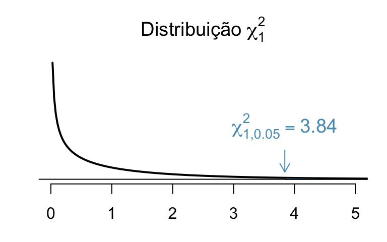

Como \(\chi^2_{obs}= 0.099 < 3.84 = \chi^2_{crit}\), não rejeitamos a hipótese nula de indepêndencia.

## Exemplo: Exercícios do Moodle e nota da Prova 1

Existe associação entre obter no mínimo 5 nos exercícios do Moodle e obter no mínimo 5 na prova 1 de ME414?

As notas de 453 alunos matriculados nas turmas de ME414 no 2S2015 foram consideradas. Os seguintes resultados foram obtidos:

|  | < 5 na P1 | >= 5 na P1 | Total |
| --- | --- | --- | --- |
| < 5 no Moodle | 21 | 44 | 65 |
| >= 5 no Moodle | 37 | 351 | 388 |
| Total | 58 | 395 | 453 |

## Exemplo: Exercícios do Moodle e nota da Prova 1

Tabela de frequências esperadas, segundo a hipótese nula de independência:

\[E_{ij}=n\hat{p}_{ij}=\frac{n_{i0}n_{0j}}{n}\]

|  | < 5 na P1 | >= 5 na P1 |
| --- | --- | --- |
| < 5 no Moodle | 8.32 | 56.68 |
| >=5 no Moodle | 49.68 | 338.32 |

A estatística \(\chi^2\) tem o valor observado de

\[\chi^2_{obs}=\frac{(21-8.32)^2}{8.32}+\frac{(44-56.68)^2}{56.68}+\frac{(37-49.68)^2}{49.68}+\frac{(351-338.32)^2}{338.32}=25.86 \stackrel{H_0}{\sim} \chi^2_{1}\]

Usando o nível de significância \(\alpha=0.05\), o valor crítico é \(\chi^2_{crit} = \chi^2_{1, 0.05} = 3.84\).

Como \(\chi^2_{obs}= 25.86 > 3.84 = \chi^2_{crit}\), rejeitamos a hipótese nula de indepêndencia.

## Teste de Homogeneidade

## Teste de Homogeneidade

Nas situações em que utilizamos os testes de independência, o esquema de amostragem utizado foi baseado numa amostra aleatória de tamanho \(n\) que é classificada com respeito a duas características simultaneamente.

Nesse caso, as frequências marginais totais (totais por linhas e totais por colunas) são variáveis aleatórias, pois a cada nova amostragem, não temos como saber de antemão quais serão os valores dos totais por linhas/colunas.

Se o esquema de amostragem for de dividir a população em duas subpopulações de acordo com as categorias de uma característica e selecionar uma amostra de um tamanho pré-determinado para cada subpopulação, então esta será uma situação de tabela de contingência com margens fixas.

## Teste de Homogeneidade

Por exemplo, no caso do problema de filiação partidária, poderíamos selecionar amostras aleatórias de tamanho \(200\) entre afiliados do partido \(A\) e \(300\) dentre os afiliados do partido \(B\) e se classificaria essas amostras de acordo com a atitude (favorável, indiferente ou contrário).

O interesse então é estudar as proporções nessas categorias para determinar se elas são aproximadamente iguais para as diferentes subpopulações. Ou seja, queremos testar se as subpopulações são homogêneas.

## Teste de Homogeneidade

Suponha que amostras aleatórias independentes de tamanho \(n_{10}, \ldots, n_{r0}\) são selecionadas de \(r\) subpopulações \(A_1, \ldots, A_r\) respectivamente. Classificando cada amostra em uma das categorias \(B_1, \ldots, B_c\), obtemos uma tabela de contigência \(r \times c\) onde os totais das linhas são tamanhos de amostras fixos.

Tabelas de contingência \(r \times c\) com totais das linhas fixos:

|  | \(B_1\) | \(B_2\) | \(\ldots\) | \(B_c\) | Total da linha |
| --- | --- | --- | --- | --- | --- |
| \(A_1\) | \(n_{11}\) | \(n_{12}\) | \(\ldots\) | \(n_{1c}\) | \(n_{10}\) |
| \(A_2\) | \(n_{21}\) | \(n_{22}\) | \(\ldots\) | \(n_{2c}\) | \(n_{20}\) |
| \(\vdots\) | \(\vdots\) | \(\vdots\) | \(\vdots\) | \(\vdots\) | \(\vdots\) |
| \(A_r\) | \(n_{r1}\) | \(n_{r2}\) | \(\ldots\) | \(n_{rc}\) | \(n_{r0}\) |
| Total da coluna | \(n_{01}\) | \(n_{02}\) | \(\ldots\) | \(n_{0c}\) | \(n\) |

## Teste de Homogeneidade

As probabilidades das várias categorias de \(B\) dentro de cada subpopulação de \(A\) também são apresentadas a seguir, onde cada \(w\) representa uma probabilidade condicional,

\[w_{ij}=P(B_j| A_i)= \text{ probabilidade de } B_j \text{ dentro da população } A_i.\]

Probabilidades das categorias de \(B\) dentro de cada subpopulação:

|  | \(B_1\) | \(B_2\) | \(\ldots\) | \(B_c\) | Total da linha |
| --- | --- | --- | --- | --- | --- |
| \(A_1\) | \(w_{11}\) | \(w_{12}\) | \(\ldots\) | \(w_{1c}\) | \(1\) |
| \(A_2\) | \(w_{21}\) | \(w_{22}\) | \(\ldots\) | \(w_{2c}\) | \(1\) |
| \(\vdots\) | \(\vdots\) | \(\vdots\) | \(\vdots\) | \(\vdots\) | \(\vdots\) |
| \(A_r\) | \(w_{r1}\) | \(w_{r2}\) | \(\ldots\) | \(w_{rc}\) | \(1\) |

## Teste de Homogeneidade

A hipótese nula de iqualdade das categorias \(B\) para as \(r\) subpopulações é:

\[H_0: w_{1j}=w_{2j}= \cdots = w_{rj}, \mbox{ para todo } j=1,2, \ldots c.\]

Sob \(H_0\), a probabilidade comum da categoria \(B_j\) pode ser estimada do conjunto de amostras notando que de um total de \(n\) elementos amostrados, \(n_{0j}\) possuem a característica \(B_j\), daí a probabilidade estimada fica

\[\hat{w}_{1j}=\hat{w}_{2j}= \cdots =\hat{w}_{rj}= \frac{n_{0j}}{n}\]

A frequência esperada estimada na componente \((i,j)\) sob \(H_0\) é:

\[\begin{aligned} E_{ij} &= (\mbox{Número de $A_i$ amostrados}) \times (\mbox{Probabilidade de $B_j$ dentro de $A_i$}) \\ &=n_{i0} \hat{w}_{ij}=\frac{n_{i0}n_{0j}}{n} \end{aligned} \]

## Teste de Homogeneidade

A **estatística do teste** é dada por:

\[\chi^2= \sum_{r \times c \text{ componentes }} \frac{(n_{ij}-E_{ij})^2}{E_{ij}}\] que sob \(H_0\) segue uma distribuição \(\chi^2\) com \((r-1)\times(c-1)\) graus de liberdade.

Pode-se observar que as fórmulas e os graus de liberdade dessa seção são iguais ao da seção anterior, somente o método de amostragem e a formalização da hipótese nula são diferentes.

**Valor Crítico**: Para um nível de significância \(\alpha\), encontrar o valor crítico \(\chi^2_{crit}\) na tabela Chi-quadrado tal que \(P(\chi^2_{(r-1)(c-1)} \geq \chi^2_{crit}) = \alpha.\)

**Conclusão**: Rejeitamos \(H_0\) se \(\chi_{obs}^2 \geq \chi^2_{crit}.\)

## Exemplo: Alcoolismo e profissões

Foi feita uma pesquisa para determinar a incidência de alcoolismo em diferentes grupos profissionais.

Separadamente, um amostra aleatória entre religiosos, educadores, executivos e comerciantes foi coletada.  
Os dados são apresentados na tabela:

|  | Alcoólatras | Não Alcoólatras |
| --- | --- | --- |
| Religiosos | 32 | 268 |
| Educadores | 51 | 199 |
| Executivos | 67 | 233 |
| Comerciantes | 83 | 267 |

## Exemplo: Alcoolismo e profissões

\[w_{ij}=P(B_j| A_i)= \text{ probabilidade de } B_j \text{ dentro da subpopulação } A_i.\]

\(H_0: w_{1j}=w_{2j}= \cdots = w_{rj}\), para todo \(j=1,2, \ldots c.\)

Tabela de contingência de alcoolismo vs profissão: frequência relativa por linha.

|  | Alcoólatras | Não Alcoólatras |
| --- | --- | --- |
| Religiosos | 0.11 | 0.89 |
| Educadores | 0.20 | 0.80 |
| Executivos | 0.22 | 0.78 |
| Comerciantes | 0.24 | 0.76 |

## Exemplo: Alcoolismo e profissões

Gráfico de barras de alcoolismo vs profissão: frequência relativa por linha.

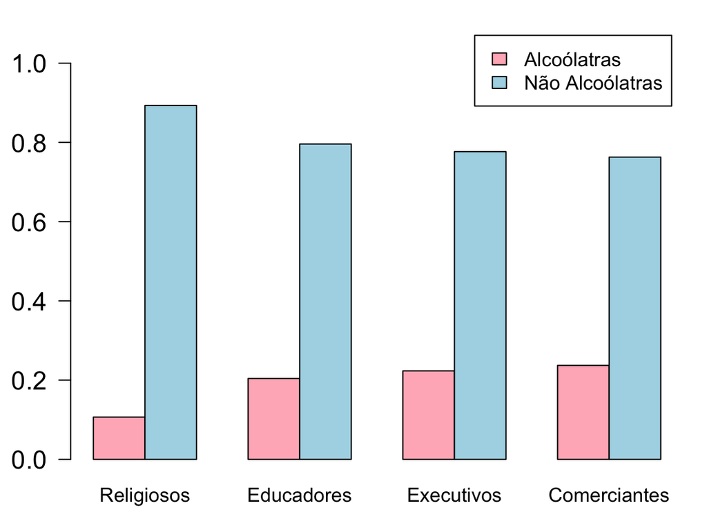

## Exemplo: Alcoolismo e profissões

A frequência esperada estimada na componente \((i,j)\) sob \(H_0\) é

\[E_{ij}=\frac{n_{i0}n_{0j}}{n}\]

Tabela de frequências esperadas, segundo a hipótese nula de homogeneidade:

|  | Alcoólatras | Não Alcoólatras |
| --- | --- | --- |
| Religiosos | 58.25 | 241.75 |
| Educadores | 48.54 | 201.46 |
| Executivos | 58.25 | 241.75 |
| Comerciantes | 67.96 | 282.04 |

## Exemplo: Alcoolismo e profissões

Representando por \(p_1, p_2, p_3\) e \(p_4\) as proporções de alcoólatras na subpopulação de religiosos, educadores, executivos e comerciantes, respectivamente, queremos testar a hipótese:

\[H_0: p_1= p_2 = p_3 = p_4 \quad \mbox{vs} \quad H_a: \mbox{pelo menos uma proporção é diferente}\]

A estatística observada é:

\[\chi^2_{obs}= \frac{(32-58.25)^2}{58.25}+ \cdots + \frac{(267-282.04)^2}{282.04}=20.6 \stackrel{H_0}{\sim} \chi^2_{3}\]

Usando o nível de significância \(\alpha=0.05\), o valor crítico é \(\chi^2_{crit} = \chi^2_{3, 0.05} = 7.81\). Como \(\chi^2_{obs}= 20.6 > 7.81 = \chi^2_{crit}\), rejeitamos a hipótese nula de homogeneidade.

Como a hipótese nula foi rejeitada verificamos que há indícios de que a proporção de alcoólatras nas classes profissionais não é homogênea.

## Exemplo: Google

O Google está constantemente elaborando experimentos para testar novos algoritmos de busca. Por exemplo, o Google pode estar interessado em testar 3 algoritmos usando uma amostra aleatória para cada um: 5000 buscas feitas com o algoritmo atual foram selecionadas ao acaso, 2500 buscas feitas com o algoritmo teste 1 foram selecionadas ao acaso e 2500 buscas feitas com o algoritmo teste 2 foram selecionadas ao acaso.

Como avaliar qual o melhor algoritmo? É preciso definir alguma medida.

No caso, o Google irá avaliar se o usuário clicou em um dos links da busca e depois não realizou uma nova tentativa de busca ou se ele depois realizou nova tentativa (indicando que a primeira busca não foi bem sucedida).

Objetivo: 3 algoritmos têm a mesma performance, isto é, a proporção de buscas que não são refeitas é a mesma para os três algoritmos?

## Exemplo: Google

Suponha que o Google tenha obtido os seguintes resultados:

|  | Atual | Teste 1 | Teste 2 |
| --- | --- | --- | --- |
| Sem nova busca | 3511 | 1749 | 1818 |
| nova busca | 1489 | 751 | 682 |

## Exemplo: Google

Tabela de frequências esperadas, segundo a hipótese nula de homogeneidade:

|  | Atual | Teste 1 | Teste 2 |
| --- | --- | --- | --- |
| Sem nova busca | 3539 | 1769.5 | 1769.5 |
| nova busca | 1461 | 730.5 | 730.5 |

Usando o nível de significância \(\alpha=0.01\), o valor crítico é \(\chi^2_{crit} = \chi^2_{2, 0.01} = 9.21\). Como \(\chi^2_{obs}= 6.12 < 9.21 = \chi^2_{crit}\), não rejeitamos a hipótese nula de homogeneidade.

## Exemplo: Google

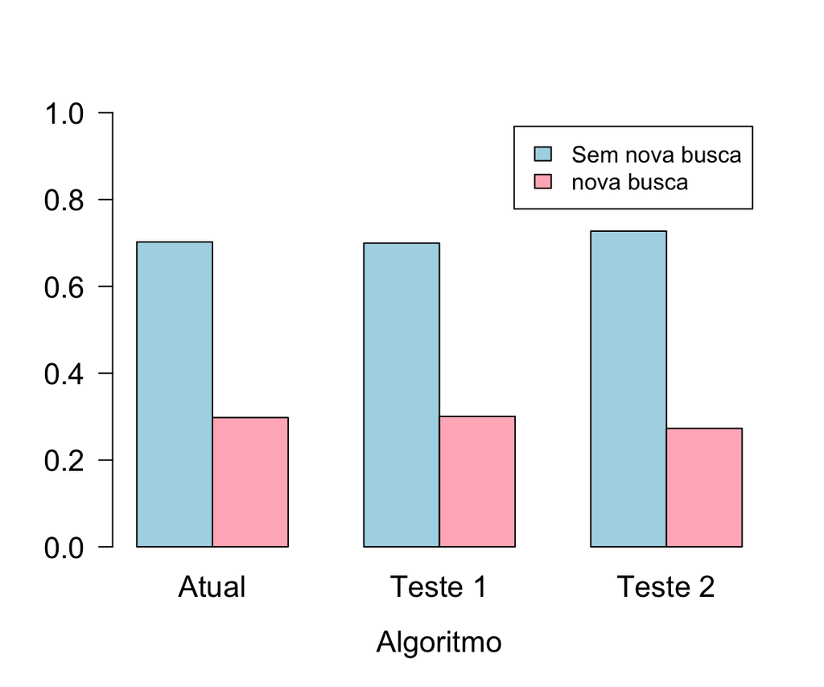

## Leituras

- [Ross](http://www.sciencedirect.com/science/article/pii/B9780123743886000132): capítulo 13.
- [OpenIntro](https://www.openintro.org/stat/textbook.php): seção 6.4

Slides produzidos pelos professores:

- Samara Kiihl
- Tatiana Benaglia
- Benilton Carvalho